# Multiple Linear Regression 02222021

sbsambado

2/22/2021

This Rmd comes from Dr. Allison Horst 206 class in the Bren department at UCSB with some <sub>slight</sub> edits for clarity by me.

Objectives - Explore multivariate data (SLO housing prices) - Perform multiple linear regression - Assess diagnostics - Compare different models by AIC - Explain model outputs - Make a nice table of regression results - Make predictions using a final model

###1. Upload necessary things

```r
# packages needed
library(tidyverse)
library(corrplot)
library(stargazer) # tables
library(psych) # pairs.panel

# data
homes <- read_csv("slo_homes.csv") # Read in data
str(homes) # 781 observations, 7 columns/variables
```

```
## spec_tbl_df [781 × 7] (S3: spec_tbl_df/tbl_df/tbl/data.frame)
##  $ City        : chr [1:781] "Arroyo Grande" "Paso Robles" "Paso Robles" "Morro Bay" ...
##  $ Price       : num [1:781] 795000 399000 545000 909000 109900 ...
##  $ Bedrooms    : num [1:781] 3 4 4 4 3 3 4 3 4 3 ...
##  $ Bathrooms   : num [1:781] 3 3 3 4 1 3 2 2 3 2 ...
##  $ SqFt        : num [1:781] 2371 2818 3032 3540 1249 ...
##  $ PricePerSqFt: num [1:781] 335 142 180 257 88 ...
##  $ Status      : chr [1:781] "Short Sale" "Short Sale" "Short Sale" "Short Sale" ...
##  - attr(*, "spec")=
##   .. cols(
##   ..   City = col_character(),
##   ..   Price = col_double(),
##   ..   Bedrooms = col_double(),
##   ..   Bathrooms = col_double(),
##   ..   SqFt = col_double(),
##   ..   PricePerSqFt = col_double(),
##   ..   Status = col_character()
##   .. )
```

```r
# NEW DATASET <- OLD DATASET
homes_sub <- homes %>% # PIPE, AND THEN WE DO THIS
  filter(City == "Arroyo Grande" | City == "San Luis Obispo" | City == "Atascadero" | City == "Santa Maria-Orcutt")

dim(homes_sub) #403 observations, 7 variables
```

```
## [1] 403   7
```

```r
str(homes_sub)
```

```
## spec_tbl_df [403 × 7] (S3: spec_tbl_df/tbl_df/tbl/data.frame)
##  $ City        : chr [1:403] "Arroyo Grande" "Santa Maria-Orcutt" "Santa Maria-Orcutt" "Santa Maria-Orcutt" ...
##  $ Price       : num [1:403] 795000 109900 192900 215000 319000 ...
##  $ Bedrooms    : num [1:403] 3 3 4 3 3 3 3 2 3 3 ...
##  $ Bathrooms   : num [1:403] 3 1 2 2 2 2 2 2 2 2 ...
##  $ SqFt        : num [1:403] 2371 1249 1603 1450 1323 ...
##  $ PricePerSqFt: num [1:403] 335 88 120 148 241 ...
##  $ Status      : chr [1:403] "Short Sale" "Short Sale" "Short Sale" "Short Sale" ...
##  - attr(*, "spec")=
##   .. cols(
##   ..   City = col_character(),
##   ..   Price = col_double(),
##   ..   Bedrooms = col_double(),
##   ..   Bathrooms = col_double(),
##   ..   SqFt = col_double(),
##   ..   PricePerSqFt = col_double(),
##   ..   Status = col_character()
##   .. )
```

```r
summary(homes_sub)
```

```
##      City               Price            Bedrooms        Bathrooms
##  Length:403         Min.   :  26500   Min.   : 1.000   Min.   : 1.00
##  Class :character   1st Qu.: 185000   1st Qu.: 3.000   1st Qu.: 2.00
##  Mode  :character   Median : 249999   Median : 3.000   Median : 2.00
##                     Mean   : 330098   Mean   : 3.186   Mean   : 2.38
##                     3rd Qu.: 365000   3rd Qu.: 4.000   3rd Qu.: 3.00
##                     Max.   :5499000   Max.   :10.000   Max.   :11.00
##       SqFt       PricePerSqFt        Status
##  Min.   : 120   Min.   :  19.33   Length:403
##  1st Qu.:1200   1st Qu.: 131.72   Class :character
##  Median :1520   Median : 161.72   Mode  :character
##  Mean   :1727   Mean   : 183.59
##  3rd Qu.:2000   3rd Qu.: 216.39
##  Max.   :6800   Max.   :1086.76
```

###2. Background on multiple linear regression

Most outcomes of interest (Y) don’t have a perfect linear relationship with only 1 explanatory variable (X). **y ~ x**

linear regression: **y** = intercept (beta0) + slope of **X** (beta1X1) + error plant height = intercept + sunlight + error *one beta (beta1) is being estimated*

multiple linear regression: **y** = intercept + slope of **X1** (beta1X1) + slope of **X2**(beta2X2) + slope of **X3**(beta3X3) + error plant height = intercept + sunlight + species + precipitation *three betas (beta1, beta2, beta3) are being estimated*

###3. Go exploring (visual) + think critically

*Note: It’s OK to LOOK at things separately, even if you’re including all in a model together!*

Example: if I want to compare distribution of housing prices by CITY (ignoring all other variables), I can do that.

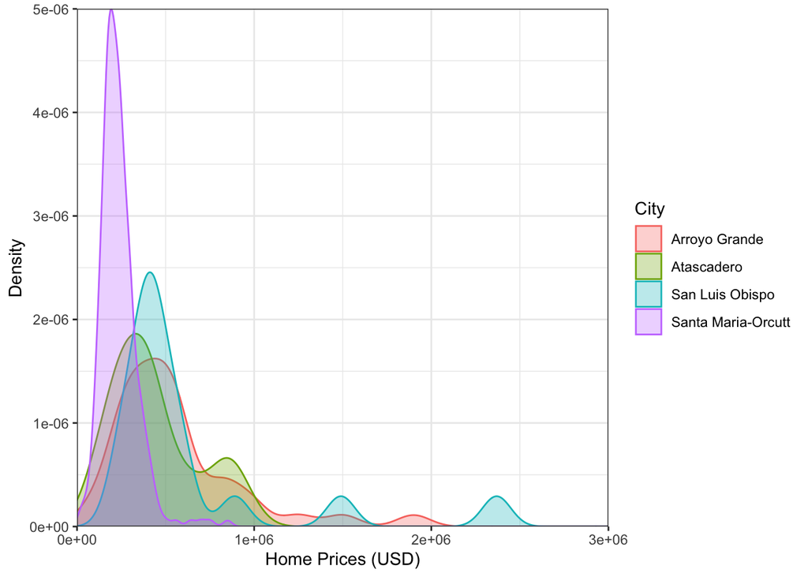

```r
# %>% is read as 'then do this'
mean_by_city <- homes_sub %>%  # create variable 'mean_by_city' with 'homes_sub', then
  group_by(City) %>%  # group by city, then
  summarize( # summarize
    mean = mean(Price) # by their mean price and make a column called 'mean'
  )

by_city <- ggplot(homes_sub, aes(x = Price)) +
  geom_density(aes(color = City, fill = City), alpha = 0.3) + # Note: show difference btween color and fill
  theme_bw() + # there's multiple themes, show theme_bw
  scale_x_continuous(expand = c(0,0), limits = c(0,3e6)) +
  scale_y_continuous(expand = c(0,0)) +
  labs(x = "Home Prices (USD)", y = "Density")
by_city
```

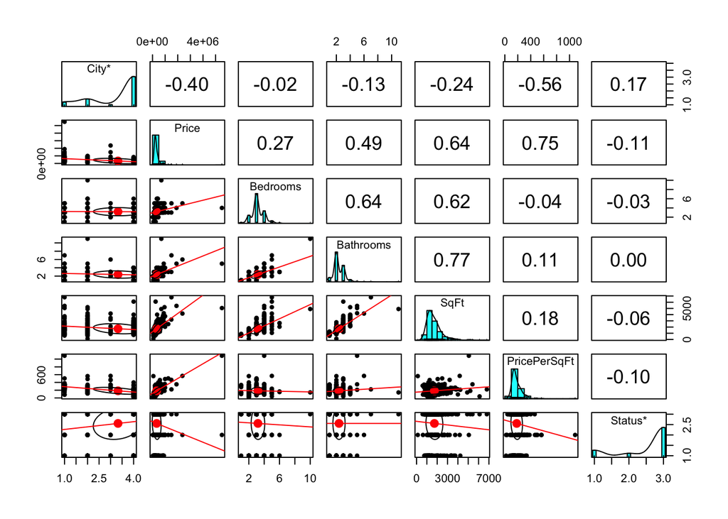

```r
# example of collinearity

# child height ~ mom's height + nutrition (2x)
# child height ~ mom's height + mom's jean length, this is high collinearity, avoid this (2X) --> 1X

pairs.panels(homes_sub, lm =TRUE)
```

```r
dim(homes_sub)
```

```
## [1] 403   7
```

```r
# correlation: y ~ x
# correlation co-efficient - 1 to 1
# - 1 negative relationship
# + 1 positive relationship
# 0 flat line, there is no relationship
```

price ~ city

Or another question: Overall relationship between home square footage and price, separated by City?

y ~ x **home price ~ square footage**

```r
# 2 numeric --> geom_point
# 1 numeric, 1 categorical --> boxplot

max(homes_sub$SqFt)
```

```
## [1] 6800
```

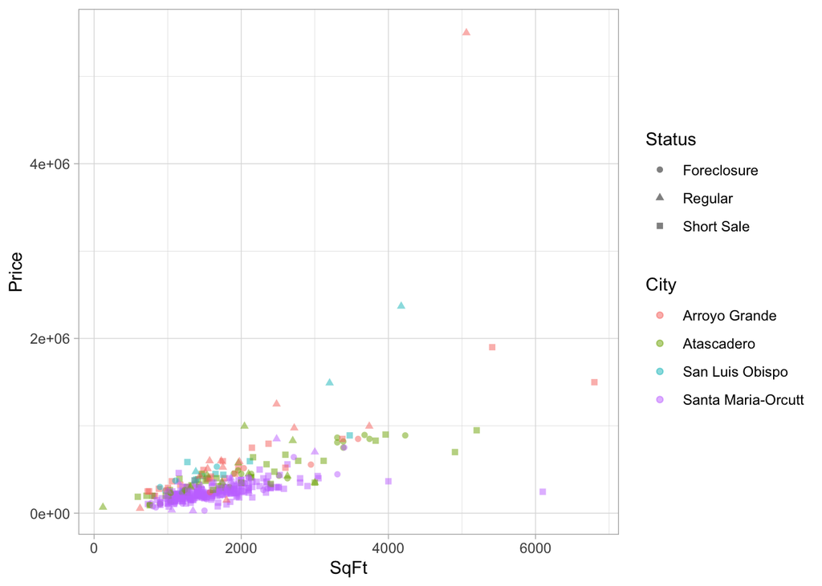

```r
by_sqft <- ggplot(homes_sub, aes(x = SqFt, y = Price)) +
  geom_point(aes(color = City, pch = Status), alpha = 0.5) +
  theme_light()
by_sqft
```

```r
# Observations here: Does relationship appear ~ linear? Anything else we can pick out re: trends, outliers, etc.? What is the general trend? Any outliers? Is there reason enough for us to omit it?
```

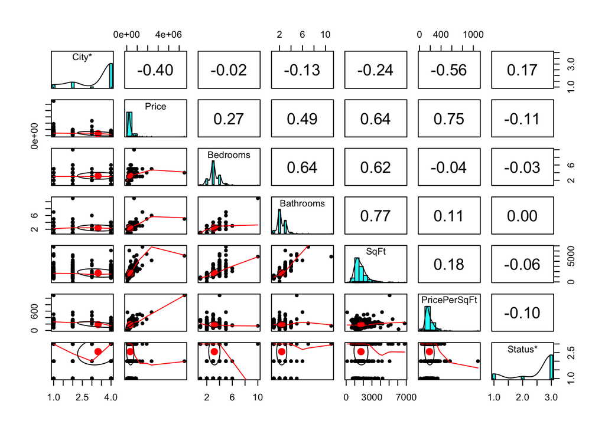

```r
# Correlation matrix: any concerns about collinearity?
pairs.panels(homes_sub)
# blue histograms are the distribution of each variable
# top right numbers are correlation coefficients,
# bottom right numbers are regression models

# play around with arguments
pairs.panels(homes_sub, cor = TRUE)
```

[output not shown]

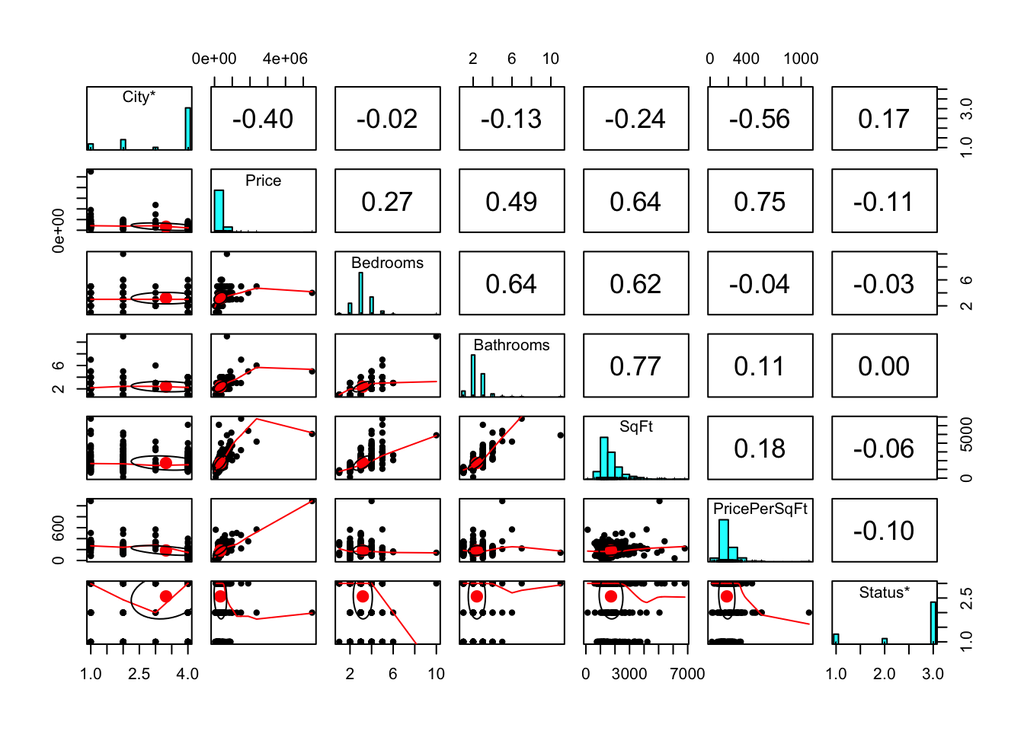

```r
pairs.panels(homes_sub, density = FALSE)
```

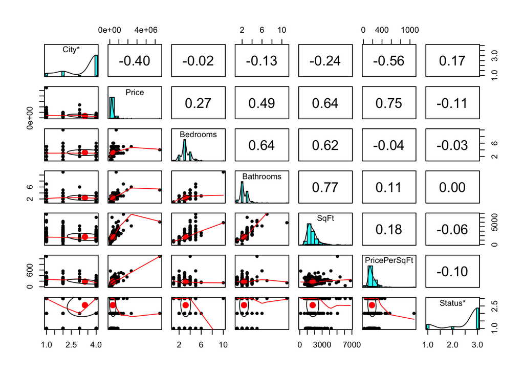

```r
pairs.panels(homes_sub, lm = FALSE)
```

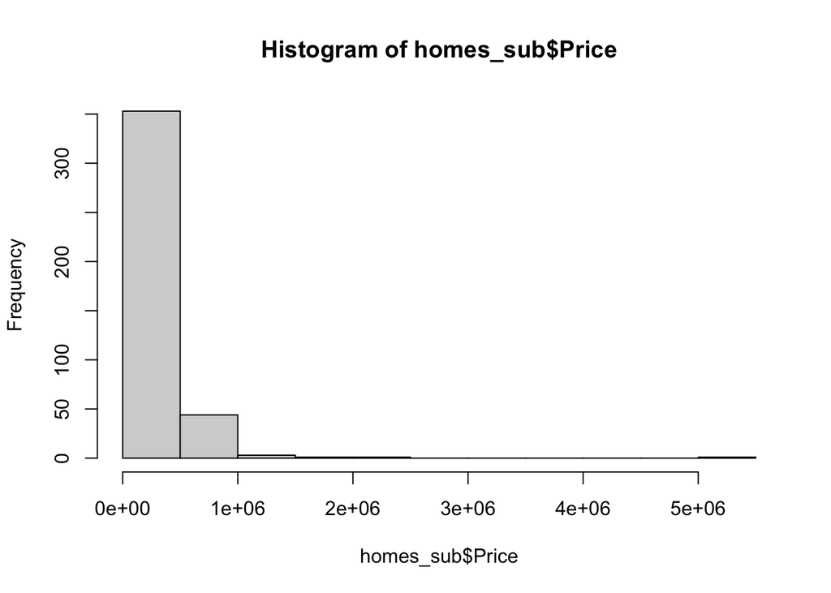

```r
# Histogram of final:
hist(homes_sub$Price) # not normal
```

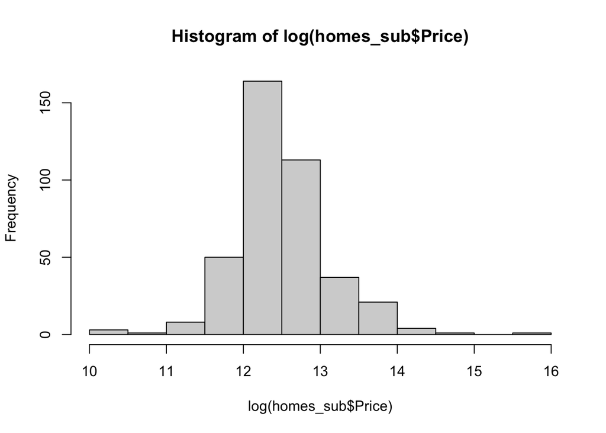

```r
hist(log(homes_sub$Price)) # more normal
```

```r
# let's make a new column for log transformed price

homes_sub$log_price <- log(homes_sub$Price) # create new colum 'log_price' in homes_sub dataset

homes_sub$log_price <- as.numeric(homes_sub$log_price)
str(homes_sub)
```

```
## spec_tbl_df [403 × 8] (S3: spec_tbl_df/tbl_df/tbl/data.frame)
##  $ City        : chr [1:403] "Arroyo Grande" "Santa Maria-Orcutt" "Santa Maria-Orcutt" "Santa Maria-Orcutt" ...
##  $ Price       : num [1:403] 795000 109900 192900 215000 319000 ...
##  $ Bedrooms    : num [1:403] 3 3 4 3 3 3 3 2 3 3 ...
##  $ Bathrooms   : num [1:403] 3 1 2 2 2 2 2 2 2 2 ...
##  $ SqFt        : num [1:403] 2371 1249 1603 1450 1323 ...
##  $ PricePerSqFt: num [1:403] 335 88 120 148 241 ...
##  $ Status      : chr [1:403] "Short Sale" "Short Sale" "Short Sale" "Short Sale" ...
##  $ log_price   : num [1:403] 13.6 11.6 12.2 12.3 12.7 ...
##  - attr(*, "spec")=
##   .. cols(
##   ..   City = col_character(),
##   ..   Price = col_double(),
##   ..   Bedrooms = col_double(),
##   ..   Bathrooms = col_double(),
##   ..   SqFt = col_double(),
##   ..   PricePerSqFt = col_double(),
##   ..   Status = col_character()
##   .. )
```

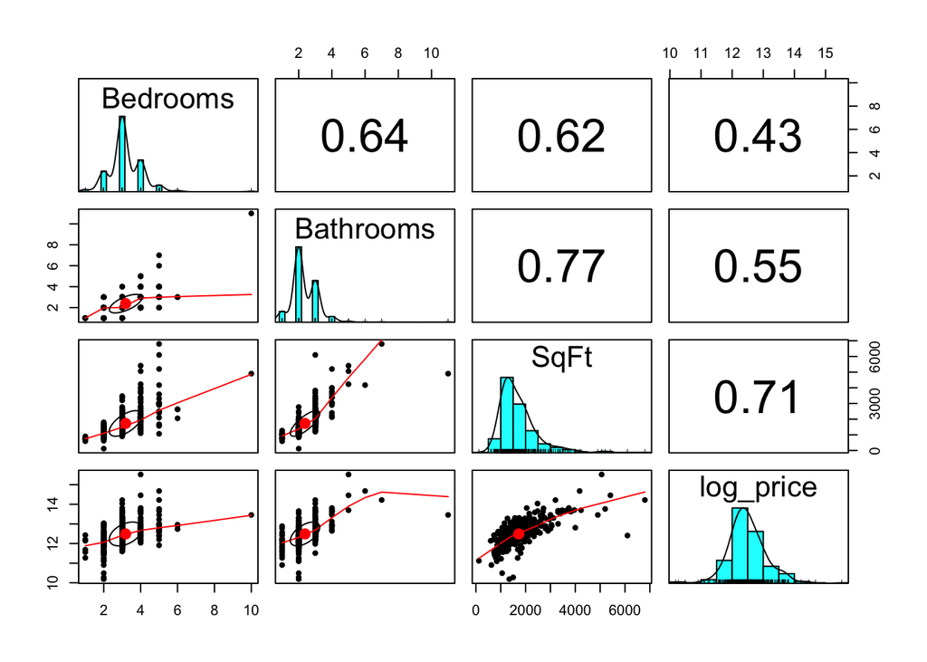

```r
# Relationships for variables we think are important:
homes_sub_import <- subset(homes_sub, select = c(3,4,5,8)) # remember to choose log price and not price
pairs.panels(homes_sub_import) # what has a high correlation coefficieent with out outcome of interest, log price?
```

At this point: any major concerns? What is going to let us know if our assumptions are really violated?

###4. Multiple linear regression

Multiple linear regression in R follows the same syntax we’ve been using so far:

```
lm(y ~ x1 + x2 + x3..., data = df_name)
```

Let’s try this model a couple of different ways:

1. Use all available variables (saturated model)
2. Use only SqFt as a predictor for “home size” generally, and omit PricePerSqFt (since it’s derived from two other existing variables in the model)

```r
homes_lm1 <- lm(Price ~ City + Bedrooms + Bathrooms + SqFt + PricePerSqFt + Status, data = homes_sub)
summary(homes_lm1)
```

```
##
## Call:
## lm(formula = Price ~ City + Bedrooms + Bathrooms + SqFt + PricePerSqFt +
##     Status, data = homes_sub)
##
## Residuals:
##     Min      1Q  Median      3Q     Max
## -965651  -47223    1947   48183 1741280
##
## Coefficients:
##                          Estimate Std. Error t value Pr(>|t|)
## (Intercept)            -626690.88   47272.70 -13.257  < 2e-16 ***
## CityAtascadero           -9068.19   29012.35  -0.313  0.75478
## CitySan Luis Obispo     -76863.04   41030.47  -1.873  0.06177 .
## CitySanta Maria-Orcutt  120160.70   28338.22   4.240 2.79e-05 ***
## Bedrooms                -30792.77   10841.58  -2.840  0.00474 **
## Bathrooms                27998.67   13251.72   2.113  0.03525 *
## SqFt                       230.73      14.31  16.126  < 2e-16 ***
## PricePerSqFt              2962.85     105.54  28.074  < 2e-16 ***
## StatusRegular           -19792.27   29484.61  -0.671  0.50244
## StatusShort Sale        -41575.71   18900.82  -2.200  0.02841 *
## ---
## Signif. codes:  0 '***' 0.001 '**' 0.01 '*' 0.05 '.' 0.1 ' ' 1
##
## Residual standard error: 138800 on 393 degrees of freedom
## Multiple R-squared:  0.8492, Adjusted R-squared:  0.8457
## F-statistic: 245.9 on 9 and 393 DF,  p-value: < 2.2e-16
```

```r
# This makes no sense! Why not? Interpret several of the coefficients (for both continuous predictors and factor levels). What should we exclude? Include? Based on WHAT?


### Looking at summary, I recommend looking at the following items

# Call: lm(y~x) formula. Make sure you are looking at the right model!

# p-value:
  # tells you if your model is a significant predictor for slopes of Xs, for this model p = < 2.2e-16 (significant!)

# F-statistic:
  #your F crit, did added coefficients improve model, for this model F = 245.9

# Intercept:
  #this is your beta0, for this model beta0 = -626690.88

# y = mx + b
# Estimates:
  #describes relationship between predictor variable & response, for this model looking at 'SqFt' estimate = 230.73

# Multple R-square:
  #how much variation can be described with your model, for this model Multiple R^2 = 0.8492
```

The next model: Excluding bedrooms and bathrooms, AND price per square foot…

```r
homes_lm2 <- lm(Price ~ City + SqFt + Status, data = homes_sub)
summary(homes_lm2) # NOW this is something that makes sense conceptually and mathematically...
```

```
##
## Call:
## lm(formula = Price ~ City + SqFt + Status, data = homes_sub)
##
## Residuals:
##      Min       1Q   Median       3Q      Max
## -1087480   -68268     8241    62660  3938242
##
## Coefficients:
##                          Estimate Std. Error t value Pr(>|t|)
## (Intercept)             106333.12   57574.57   1.847   0.0655 .
## CityAtascadero         -202157.51   49077.01  -4.119 4.63e-05 ***
## CitySan Luis Obispo      34525.41   70837.96   0.487   0.6263
## CitySanta Maria-Orcutt -275841.28   42992.76  -6.416 4.00e-10 ***
## SqFt                       245.93      15.33  16.048  < 2e-16 ***
## StatusRegular           209998.86   49636.98   4.231 2.90e-05 ***
## StatusShort Sale          2282.42   32894.07   0.069   0.9447
## ---
## Signif. codes:  0 '***' 0.001 '**' 0.01 '*' 0.05 '.' 0.1 ' ' 1
##
## Residual standard error: 243100 on 396 degrees of freedom
## Multiple R-squared:  0.5339, Adjusted R-squared:  0.5268
## F-statistic:  75.6 on 6 and 396 DF,  p-value: < 2.2e-16
```

```r
# Interpret coefficients for City, SqFt, and Status. Do these make sense based on what you know about housing prices?
## you tell me,

# what is the
  # y~x(s) relationship that you are investigating?
  # what if your p-pvalue? #  p-value: < 2.2e-16
  # what is your F-statistic?
  # what is your intercept (beta0)? # 106333.12
  # what is an estimate for a strong predictor variable?
  # what is your multiple R^2? # 0.5339 --> 53% of variation is explained by model homes_lm2
```

Wait…but what if I wanted everything to be with respect to a Regular sale status? Then I need to change my factor levels. We’ve done this before, here we’ll use a different function (fct_relevel) from *forcats* package in the tidyverse.

**Remember** factor is a grouping, levels are the individuals groups within a factor

- i.e. mammal is a factor, levels can be dog,cat,human
- responses can only fall into discrete bins of your levels, so it is not considered a numeric despite having levels with numbers

```r
str(homes_sub) # there are currently no factors in this dataset, just because R reads your data a certain way doesn't mean R truly gets your data and questions like you do!
```

```
## spec_tbl_df [403 × 8] (S3: spec_tbl_df/tbl_df/tbl/data.frame)
##  $ City        : chr [1:403] "Arroyo Grande" "Santa Maria-Orcutt" "Santa Maria-Orcutt" "Santa Maria-Orcutt" ...
##  $ Price       : num [1:403] 795000 109900 192900 215000 319000 ...
##  $ Bedrooms    : num [1:403] 3 3 4 3 3 3 3 2 3 3 ...
##  $ Bathrooms   : num [1:403] 3 1 2 2 2 2 2 2 2 2 ...
##  $ SqFt        : num [1:403] 2371 1249 1603 1450 1323 ...
##  $ PricePerSqFt: num [1:403] 335 88 120 148 241 ...
##  $ Status      : chr [1:403] "Short Sale" "Short Sale" "Short Sale" "Short Sale" ...
##  $ log_price   : num [1:403] 13.6 11.6 12.2 12.3 12.7 ...
##  - attr(*, "spec")=
##   .. cols(
##   ..   City = col_character(),
##   ..   Price = col_double(),
##   ..   Bedrooms = col_double(),
##   ..   Bathrooms = col_double(),
##   ..   SqFt = col_double(),
##   ..   PricePerSqFt = col_double(),
##   ..   Status = col_character()
##   .. )
```

```r
# How to transform a chr or num to a value
# HINT: DATAFRAME$NEW_VARIABLE <- factor(DATAFRAME$OLD_VARIABLE)
homes_sub$Status <- factor(homes_sub$Status)

# Check to ensure it's a factor now
class(homes_sub$Status) # Yay! A factor
```

```
## [1] "factor"
```

```r
# Check levels:
levels(homes_sub$Status) # Current reference level is 'Foreclosure'
```

```
## [1] "Foreclosure" "Regular"     "Short Sale"
```

```r
# Reassign reference level of "Status" to "Regular":
homes_sub$Status <- fct_relevel(homes_sub$Status, "Regular")

# Now run the regression again - same equation, but now the reference levels are different!
homes_lm3 <- lm(Price ~ City + SqFt + Status, data = homes_sub)
summary(homes_lm3)
```

```
##
## Call:
## lm(formula = Price ~ City + SqFt + Status, data = homes_sub)
##
## Residuals:
##      Min       1Q   Median       3Q      Max
## -1087480   -68268     8241    62660  3938242
##
## Coefficients:
##                          Estimate Std. Error t value Pr(>|t|)
## (Intercept)             316331.97   59022.44   5.360 1.42e-07 ***
## CityAtascadero         -202157.51   49077.01  -4.119 4.63e-05 ***
## CitySan Luis Obispo      34525.41   70837.96   0.487    0.626
## CitySanta Maria-Orcutt -275841.28   42992.76  -6.416 4.00e-10 ***
## SqFt                       245.93      15.33  16.048  < 2e-16 ***
## StatusForeclosure      -209998.86   49636.98  -4.231 2.90e-05 ***
## StatusShort Sale       -207716.44   43222.29  -4.806 2.19e-06 ***
## ---
## Signif. codes:  0 '***' 0.001 '**' 0.01 '*' 0.05 '.' 0.1 ' ' 1
##
## Residual standard error: 243100 on 396 degrees of freedom
## Multiple R-squared:  0.5339, Adjusted R-squared:  0.5268
## F-statistic:  75.6 on 6 and 396 DF,  p-value: < 2.2e-16
```

```r
# Question: What happens if you run all of this, then go back to the code chunk above and run that code again? It'll change there TOO...remember, information in R is stored.

# Now: How do we interpret the coefficients for Short Sale/Foreclosure vs. Regular sales?
```

Interpret the statistical outcomes above.

###5. Model diagnostics

Remember, since we’re concerned about *residuals* (distance that actual observations exist from model predictions), we can only evaluate some assumptions *after* running the regression.

Then we can evaluate model diagnostics using the plot() function:

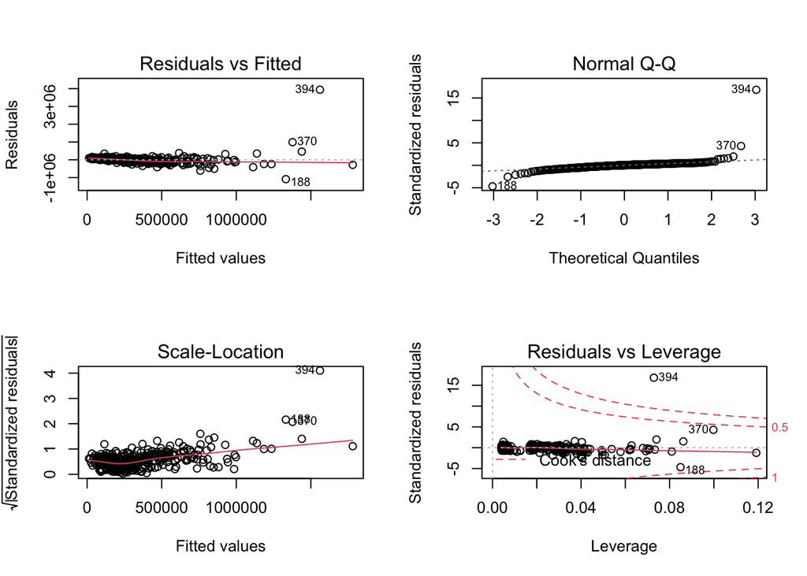

```r
par(mfrow = c(2,2))
plot(homes_lm3) # Price ~ City + SqFt + Status
```

```r
# Nothing really concerning...but there are errors. What variables do you think might be missing from the models that could account for some of the error?
# Some examples: Lot size (yard?), ocean view, etc.
# But overall, looks good and makes sense!
```

###6. Model comparison by Akaike Information Criterion

The AIC is a quantitative metric for model “optimization” that balances complexity with model fit. The best models are the ones that fit the data as well as possible, as simply as possible. Recall: lower AIC value indicates a *more optimal* balance - **BUT STATISTICS IS NO SUBSTITUTE FOR JUDGEMENT!!!**

```r
# Price ~ City + Bedrooms + Bathrooms + SqFt + PricePerSqFt + Status
(sat_aic <- AIC(homes_lm1)) # 10699
```

```
## [1] 10699.25
```

```r
# Price ~ City + SqFt + Status
(final_aic <- AIC(homes_lm3)) # 11148
```

```
## [1] 11148
```

```r
# BUT WHICH ONE WOULD YOU PICK ANYWAY???? Only a ~4% difference in AIC value...not that different in the scheme of things, and the first one doesn't make sense...so still stick with the second one! Also rules of parsimony - the simpler the better!
```

###7. Regression tables with *stargazer*

```r
lm_tab <- stargazer(homes_lm1, homes_lm3, type = "html")
```

|  | *Dependent variable:* |  |
| --- | --- | --- |
|  | Price |  |
|  | (1) | (2) |
| CityAtascadero | -9,068.194 | -202,157.500*** |
|  | (29,012.350) | (49,077.010) |
| CitySan Luis Obispo | -76,863.040* | 34,525.410 |
|  | (41,030.470) | (70,837.960) |
| CitySanta Maria-Orcutt | 120,160.700*** | -275,841.300*** |
|  | (28,338.220) | (42,992.760) |
| Bedrooms | -30,792.770*** |  |
|  | (10,841.580) |  |
| Bathrooms | 27,998.670** |  |
|  | (13,251.720) |  |
| SqFt | 230.726*** | 245.934*** |
|  | (14.308) | (15.325) |
| PricePerSqFt | 2,962.850*** |  |
|  | (105.537) |  |
| StatusRegular | -19,792.270 |  |
|  | (29,484.610) |  |
| StatusForeclosure |  | -209,998.900*** |
|  |  | (49,636.970) |
| StatusShort Sale | -41,575.710** | -207,716.400*** |
|  | (18,900.820) | (43,222.290) |
| Constant | -626,690.900*** | 316,332.000*** |
|  | (47,272.690) | (59,022.440) |
| Observations | 403 | 403 |
| R<sup>2</sup> | 0.849 | 0.534 |
| Adjusted R<sup>2</sup> | 0.846 | 0.527 |
| Residual Std. Error | 138,805.900 (df = 393) | 243,102.100 (df = 396) |
| F Statistic | 245.896*** (df = 9; 393) | 75.603*** (df = 6; 396) |
| *Note:* | p<0.1; p<0.05; p<0.01 |  |

```r
# Note: If you want to work with this in Word, save to html, open, copy and paste into Word.
```

###8. Making predictions

Using your final selected model, predict the housing price for a range of home sizes, sale status, and city.

The predict() function uses the following syntax:

```
  predict(model_name, newdata = new_data_name)
```

Defaults are to exclude the prediction SE and mean confidence interval - if you want to include, use arguments

```
  se.fit = TRUE
  interval = "confidence"
  interval = "prediction"
```

First, you need to create a new data frame of values that contain ALL NECESSARY VARIABLES **with the same variable names AND level strings**.

```r
# First, make a new data frame
# Note that the df_new created below has the SAME variable names and level strings as the original model data (otherwise R won't know how to use it...)
# Work through this on your own to figure out what it actually does:
df_new <- data.frame(City = rep(c("San Luis Obispo",
                                  "Santa Maria-Orcutt",
                                  "Atascadero",
                                  "Arroyo Grande"),
                                each = 60),
                     SqFt = rep(seq(from = 500,
                                    to = 3500,
                                    length = 20),
                                times = 12),
                     Status = rep(c("Regular",
                                    "Foreclosure",
                                    "Short Sale"),
                                  times = 12,
                                  each = 20))
```

Make predictions for the new data using predict():

```r
price_predict <- predict(homes_lm3, newdata = df_new, se.fit = TRUE, interval = "confidence") # Makes prediction
# Bind to the data to make it actually useful:
predict_df <- data.frame(df_new, price_predict)
```

Then visualize it!

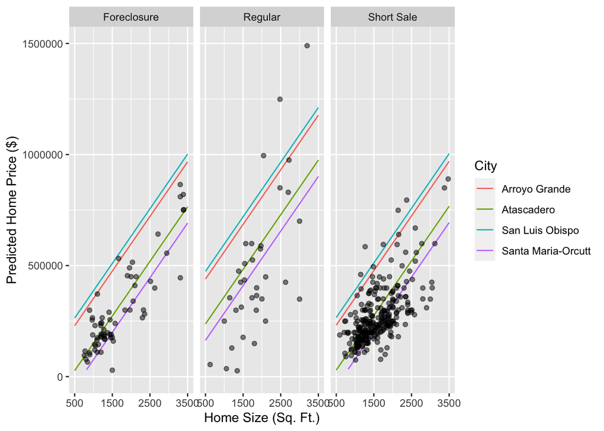

[output not shown]

[output cut: 372 more lines]

[output not shown]